# Lab 3b - Effective network graphic design

Douglas Luke

July 27, 2021

## Introduction

This lab corresponds to Chapter 5 - Effective Network Graphic Design.

Note the new package that we’re using here. Make sure to install the RColorBrewer package before running the following code.

```r
library(statnet)
library(UserNetR)
library(RColorBrewer)
```

## Nodes

### Node color

Node color can be used to make a network graphic more attractive. More usefully, we can set nodes to a particular color based on a (usually categorical) node attribute.

R refers to colors in many different ways.

Most simply, you can specify a color by its built-in name.

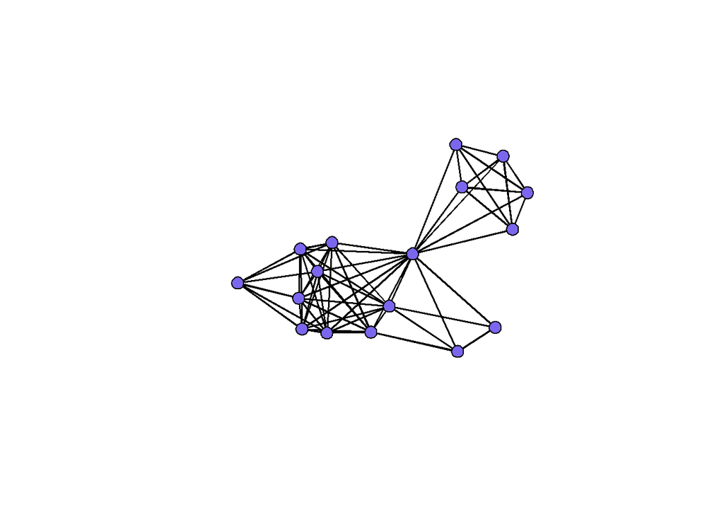

```r
data(Bali)
gplot(Bali,vertex.col="slateblue2",gmode="graph")
```

E: Use `colors()` to see the various color names. Try some of them out.

More precise color control can be obtained by using its RGB (red-green-blue) code or its underlying hexadecimal code.

```r
col2rgb('slateblue2')
```

```
##       [,1]
## red    122
## green  103
## blue   238
```

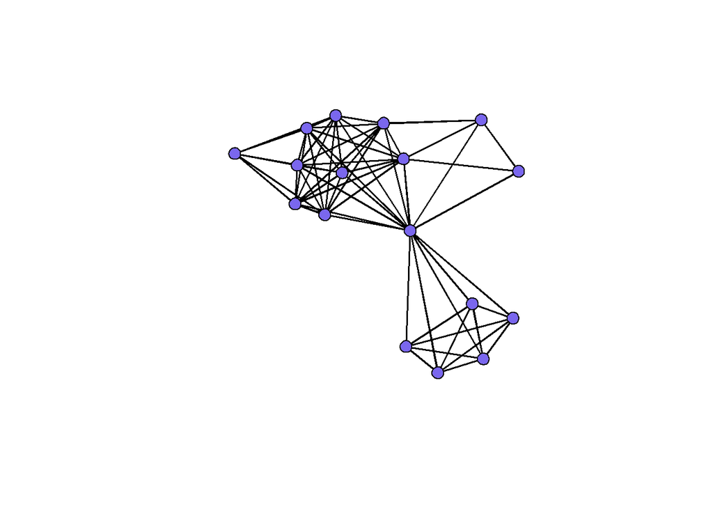

```r
gplot(Bali,vertex.col=rgb(122,103,238,
                maxColorValue=255),gmode="graph")
```

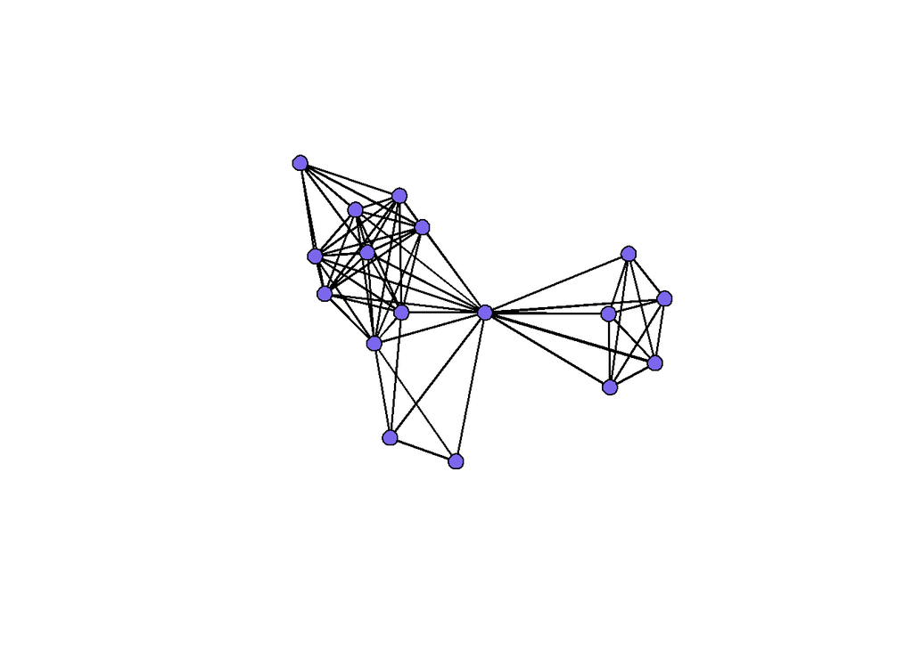

```r
gplot(Bali,vertex.col="#7A67EE",gmode="graph")
```

E: Try picking a color at paletton.com and using it in the network graphic.

An advanced color feature is to use the alpha channel to plot nodes with semi-transparent colors.

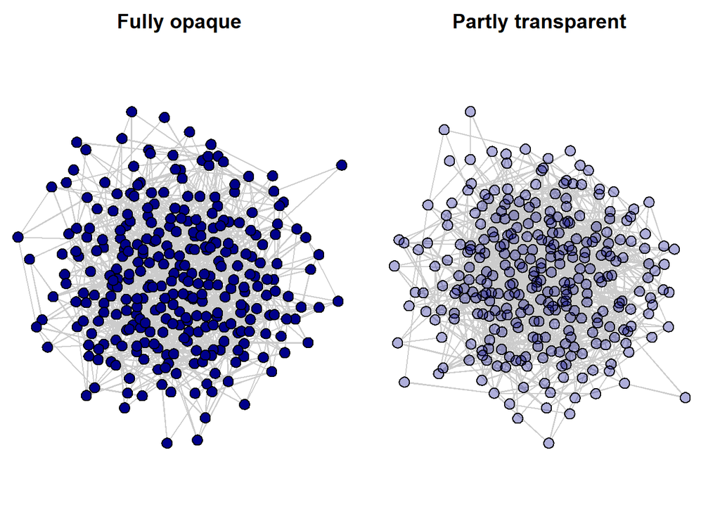

```r
ndum <- rgraph(300,tprob=0.025,mode="graph")
op <- par(mar = c(0,0,2,0),mfrow=c(1,2))
gplot(ndum,gmode="graph",vertex.cex=2,
      vertex.col=rgb(0,0,139,maxColorValue=255),
      edge.col="grey80",edge.lwd=0.5,
      main="Fully opaque")
gplot(ndum,gmode="graph",vertex.cex=2,
      vertex.col=rgb(0,0,139,alpha=80,
                     maxColorValue=255),
      edge.col="grey80",edge.lwd=0.5,
      main="Partly transparent")
```

```r
par(op)
```

Q: What network is being plotted above?

The power of node color is unlocked when we set different nodes to different colors. Typically, we will communicate information about a node characteristic (e.g., gender) by setting nodes to different colors based on that characteristic.

(Note the simpler version of the code below compare to in the book.)

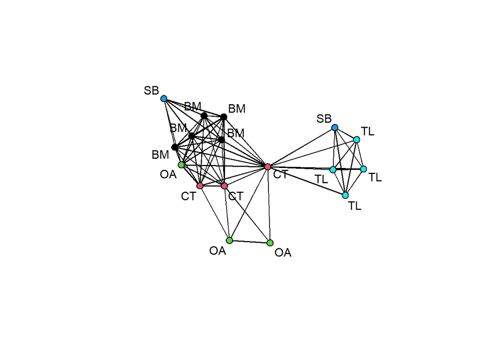

```r
plot(Bali,usearrows=FALSE,vertex.cex=1.5,label="role",
    displaylabels=T,vertex.col="role")
```

Q: How does R know which colors to use here? Hint: Try out the `palette()` function.

The color palette system in R allows you to pick sets of colors that will work well together.

```r
my_pal <- brewer.pal(5,"Dark2")
my_pal
```

```
## [1] "#1B9E77" "#D95F02" "#7570B3" "#E7298A" "#66A61E"
```

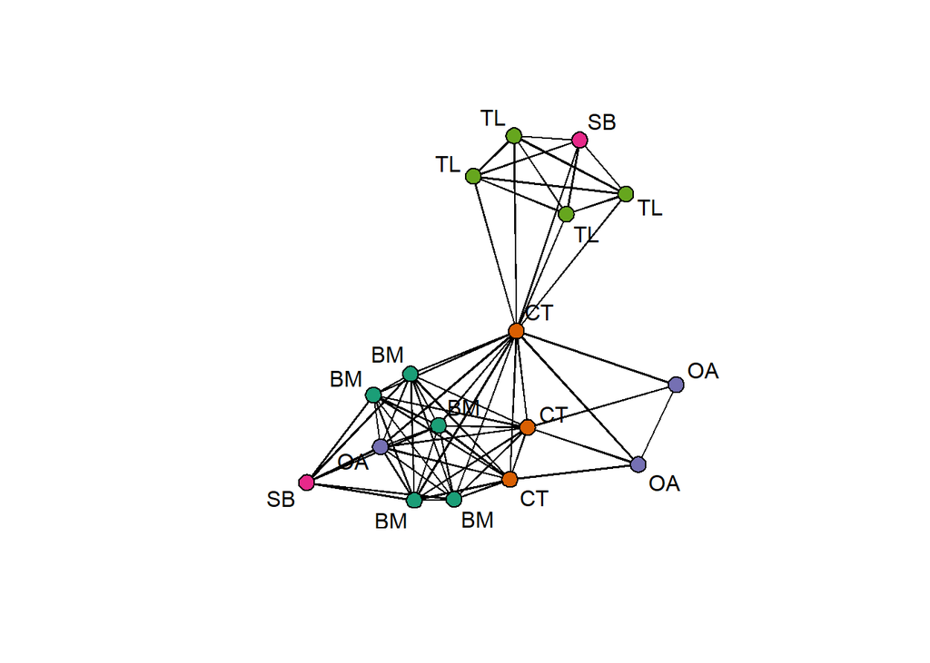

```r
rolelab <- get.vertex.attribute(Bali,"role")
rolecat <- as.factor(get.vertex.attribute(Bali,"role"))
plot(Bali,vertex.cex=2,label=rolelab,
    displaylabels=T,vertex.col=my_pal[rolecat])
```

E: Explore the palettes that are defined in RColorBrewer using `display.brewer.all()`. Pick a different palette and use it to plot the network above.

E: Create your own palette using an online tool such as paletton.com or coolors.co, and use it to plot the Bali network.

### Node size

Just like color, node size can be set for aesthetics, or to communicate some information about the nodes.

If the following graph doesn’t look right, just run each plot command one at a time.

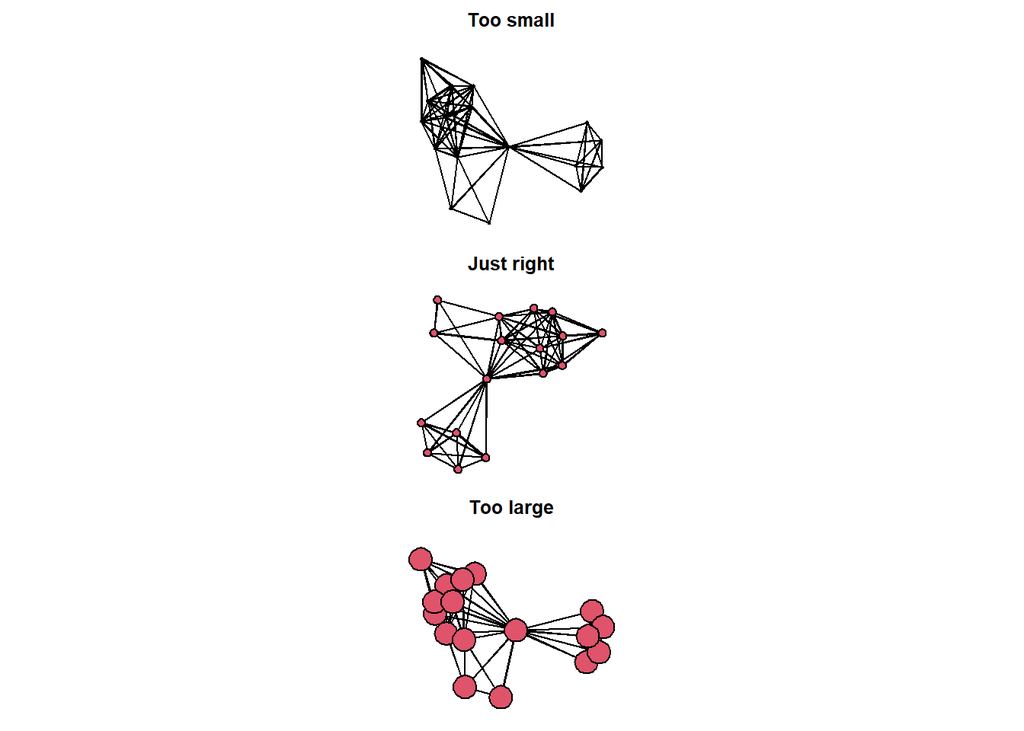

```r
op <- par(mar = c(0,0,2,0),mfrow=c(3,1))
plot(Bali,vertex.cex=0.5,main="Too small")
plot(Bali,vertex.cex=2,main="Just right")
plot(Bali,vertex.cex=6,main="Too large")
```

```r
par(op)
```

More usefully, we can set size based on an interesting characteristic of the node, such as centrality (to be covered in more detail in a later lecture).

```r
deg <- degree(Bali,gmode="graph")
deg
```

```
##  [1]  9  4  9 15  9 10  3  9  9  5  5  5  5  5  9  6  9
```

```r
cls <- closeness(Bali,gmode="graph")
cls
```

```
##  [1] 0.6956522 0.5517241 0.6956522 0.9411765 0.6956522 0.7272727 0.5333333
##  [8] 0.6956522 0.6956522 0.5714286 0.5714286 0.5714286 0.5714286 0.5714286
## [15] 0.6956522 0.4848485 0.6956522
```

```r
bet <- betweenness(Bali,gmode="graph")
bet
```

```
##  [1]  2.3333333  0.3333333  1.6666667 61.1666667  1.6666667  6.1666667
##  [7]  0.0000000  1.6666667  1.6666667  0.0000000  0.0000000  0.0000000
## [13]  0.0000000  0.0000000  1.6666667  0.0000000  1.6666667
```

Use these centrality measures to set the size of the nodes.

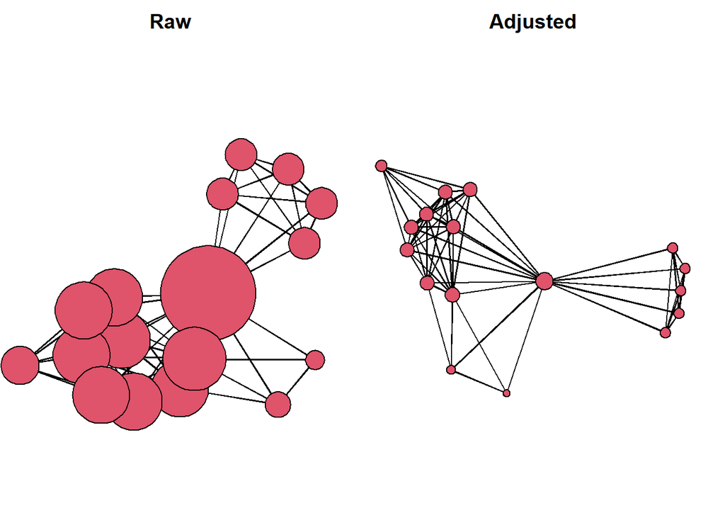

```r
op <- par(mar = c(0,0,2,1),mfrow=c(1,2))
plot(Bali,usearrows=T,vertex.cex=deg,main="Raw")
plot(Bali,usearrows=FALSE,vertex.cex=log(deg),
     main="Adjusted")
```

```r
par(op)
```

E: Use the other centrality measures in the network plot.

Rescaling node sizes is often done by trial and error (see book for more details). However, a simple function proves useful here.

```r
rescale <- function(nchar,low,high) {
  min_d <- min(nchar)
  max_d <- max(nchar)
  rscl <- ((high-low)*(nchar-min_d))/(max_d-min_d)+low
  rscl
}
```

The above code demonstrates one of the great strengths of R. Since R is actually a statistical programming language, we can extend R by writing new functions. Essentially, we have just added a new command to R, called `rescale()`. We can use it to make it easier to rescale a numeric vector of node characteristics, to facilitate plotting.

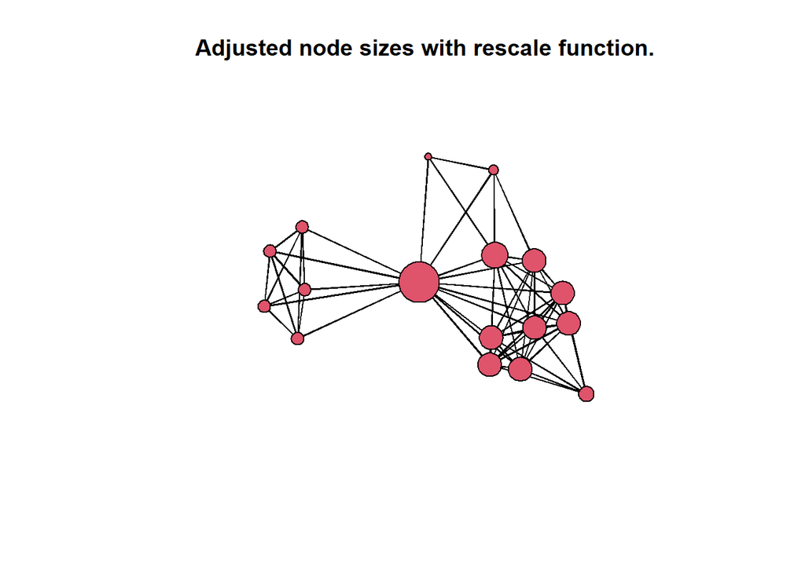

```r
plot(Bali,vertex.cex=rescale(deg,1,6),
     main="Adjusted node sizes with rescale function.")
```

E: Adjust the rescaling parameters. Also redo the network graphic using betweenness and closeness centrality, while also using the rescale function.

### Node labels

Node labels can be informative, especially for networks with smaller numbers of nodes, and with nodes that have some meaning for the audience.

```r
get.vertex.attribute(Bali,"vertex.names")
```

```
##  [1] "Muklas"   "Amrozi"   "Imron"    "Samudra"  "Dulmatin" "Idris"
##  [7] "Mubarok"  "Husin"    "Ghoni"    "Arnasan"  "Rauf"     "Octavia"
## [13] "Hidayat"  "Junaedi"  "Patek"    "Feri"     "Sarijo"
```

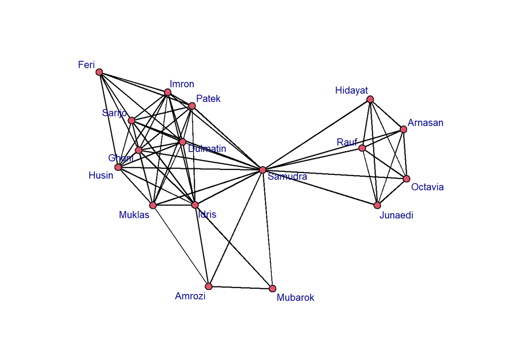

```r
op <- par(mar = c(0,0,0,0))
plot(Bali,displaylabels=TRUE,label.cex=0.8,
     pad=0.4,label.col="darkblue")
```

```r
par(op)
```

Can use any other character field to label the nodes, if it would be useful.

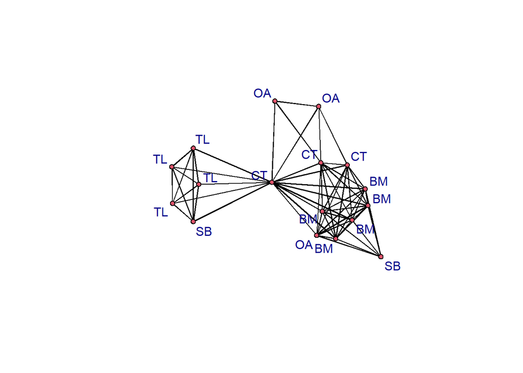

```r
plot(Bali,usearrows=FALSE,label="role",
    displaylabels=T,label.col="darkblue")
```

E: How might you selectively label only some of the nodes? For example, how might you use the network member name for Bali, but only if degree is > 9? (Hint: Use `ifelse()` to create a new node attribute.)

## Edges

### Edge width

If you have a valued network, then it is sometimes useful to set the edge width to correspond to tie strength.

In the Bali network, `IC` is a tie attribute that measures the extent of communication between two network members.

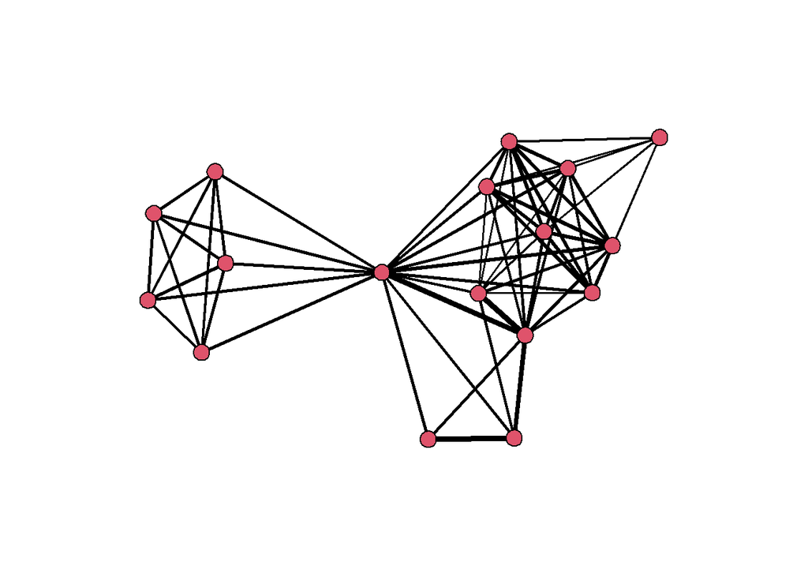

```r
op <- par(mar = c(0,0,0,0))
IClevel <- Bali %e% "IC"
plot(Bali,vertex.cex=1.5,
    edge.lwd=1.5*IClevel)
```

```r
par(op)
```

### Edge color

Just as nodes can have different colors, so can edges.

The following is not a realistic example, but demonstrates random selection of colors for each tie.

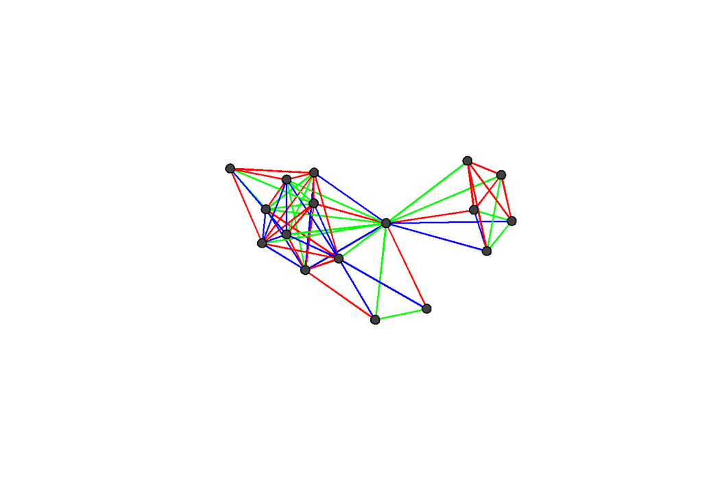

```r
n_edge <- network.edgecount(Bali)
edge_cat <- sample(1:3,n_edge,replace=T)
linecol_pal <- c("blue","red","green")
plot(Bali,vertex.cex=1.5,vertex.col="grey25",
     edge.col=linecol_pal[edge_cat],edge.lwd=2)
```

Q: How might you use one of the named R colors to help de-emphasize network ties in a network graphic?

E: Using what you have learned, take the Simpsons network and create the best and most informative graphic that you can. Use the `group` node attribute, and size nodes based on a reasonable measure of centrality. Finally, choose a layout that works best for the graphic.